# CP07_Causal_Impact_BWm-VOW

FRANCISCO DEL VAL

13/12/2020

### Objetivo

Volkswagen había instalado ilegalmente un software para alterar las emisiones contaminantes en 11 millones de automóviles con motor diésel, vendidos entre 2009 y 2015. Como resultado de este fraude, sus motores habían superado con creces los estándares de la Agencia de Protección Ambiental de Estados Unidos (EPA). Los vehículos implicados emiten en condiciones reales hasta 40 veces el límite legal de óxidos de nitrógeno.

A continuación, vamos a observar la evolución de ambas empresas desde Enero de 2014 hasta Diciembre de 2020. Para ello, utilizaremos la función CausalImpact y dvidiremos los datos en antes y después de la intevención para conocer cómo hubiera evolucionado cada empresa si no se hubiera producido el diesel gate.

### BMW

```
## Posterior inference {CausalImpact}
##
##                          Average       Cumulative
## Actual                   67            87331
## Prediction (s.d.)        64 (7.4)      83242 (9656.8)
## 95% CI                   [49, 78]      [64222, 101868]
##
## Absolute effect (s.d.)   3.1 (7.4)     4089.4 (9656.8)
## 95% CI                   [-11, 18]     [-14537, 23109]
##
## Relative effect (s.d.)   4.9% (12%)    4.9% (12%)
## 95% CI                   [-17%, 28%]   [-17%, 28%]
##
## Posterior tail-area probability p:   0.35158
## Posterior prob. of a causal effect:  65%
##
## For more details, type: summary(impact, "report")
```

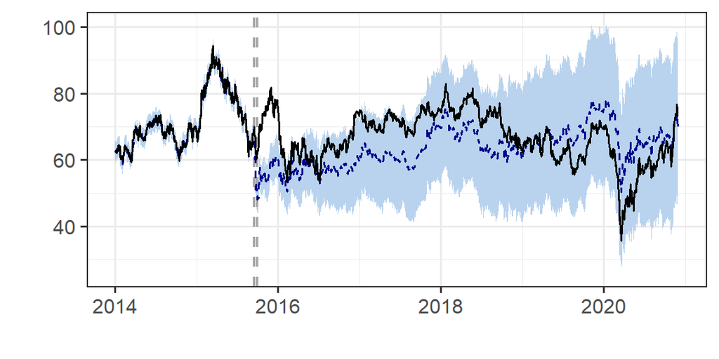

En la gráfica anterior, podemos observar que la línea vertical representa el momento de la intevención, la línea negra representa la evolución real del valor de BMW y la azul la estimación en caso de no haberse producido el fraude.

### Volkswagen

```
## Posterior inference {CausalImpact}
##
##                          Average       Cumulative
## Actual                   136           178652
## Prediction (s.d.)        146 (18)      191853 (23374)
## 95% CI                   [111, 181]    [145913, 236992]
##
## Absolute effect (s.d.)   -10 (18)      -13201 (23374)
## 95% CI                   [-45, 25]     [-58340, 32739]
##
## Relative effect (s.d.)   -6.9% (12%)   -6.9% (12%)
## 95% CI                   [-30%, 17%]   [-30%, 17%]
##
## Posterior tail-area probability p:   0.28589
## Posterior prob. of a causal effect:  71%
##
## For more details, type: summary(impact, "report")
```

Lo representamos graficamente:

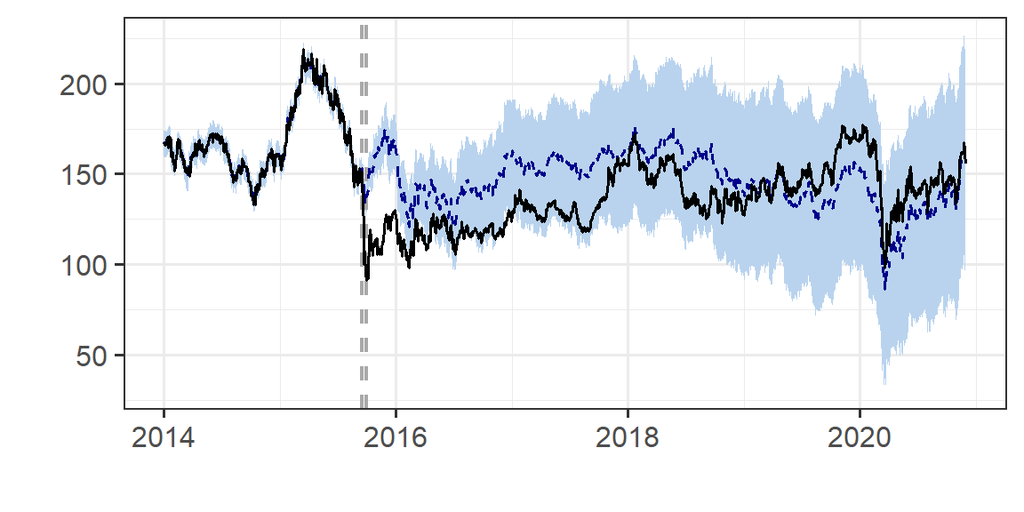

Por último, generamos un reporte con los resultados obtenidos para BMW y Volkswagen:

- BMW

[output not shown]

- Volkswagen

[output not shown]